# EDA

## diabetes_012 vs education

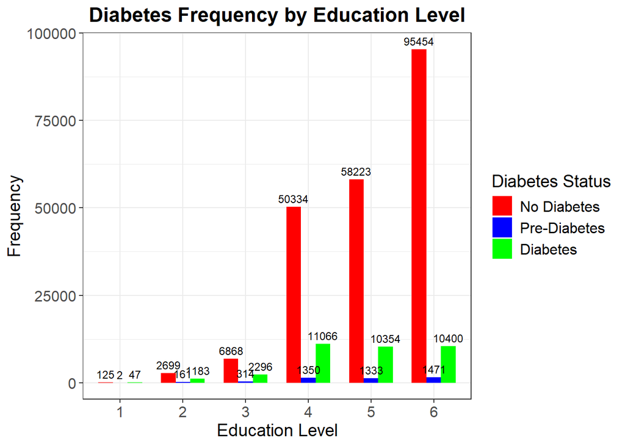

```r
# Tạo tần suất của các nhóm
freq_data <- as.data.frame(table(data$education, data$diabetes_012))
colnames(freq_data) <- c("education", "diabetes_012", "frequency")

# Chuyển đổi cột thành kiểu số
freq_data$education <- as.factor(freq_data$education)
freq_data$diabetes_012 <- as.factor(freq_data$diabetes_012)

# Vẽ biểu đồ
ggplot(freq_data, aes(x = education, y = frequency, fill = diabetes_012)) +
    geom_bar(stat = "identity", position = "dodge", width = 0.7) +
    geom_text(aes(label = frequency),
                        position = position_dodge(width = 0.7),
                        vjust = -0.5,
                        size = 3) +
    labs(
        title = "Diabetes Frequency by Education Level",
        x = "Education Level",
        y = "Frequency",
        fill = "Diabetes Status"
    ) +
    scale_fill_manual(
        values = c("red", "blue", "green"),
        labels = c("No Diabetes", "Pre-Diabetes", "Diabetes")
    ) +
    theme_bw() +
    theme(
        plot.title = element_text(size = 16, face = "bold", hjust = 0.5),
        axis.title = element_text(size = 14),
        axis.text = element_text(size = 12),
        legend.title = element_text(size = 14),
        legend.text = element_text(size = 12)
    )
```

**Trình độ học vấn 1 - 3**: - **Mức 1**: Nhóm **Không tiểu đường** rất thấp (125), và nhóm **Tiểu đường** chỉ là 47. - **Mức 2**: Nhóm **Không tiểu đường** tăng lên 2,699, và nhóm **Tiểu đường** tăng lên 1,183. - **Mức 3**: Nhóm **Không tiểu đường** là 6,868, và nhóm **Tiểu đường** đạt 2,296.

**Trình độ học vấn 4 - 6**: - **Mức 4**: Nhóm **Không tiểu đường** tăng mạnh lên 50,334, và nhóm **Tiểu đường** đạt 11,066. - **Mức 5**: Nhóm **Không tiểu đường** đạt 58,223, và nhóm **Tiểu đường** là 10,354. - **Mức 6**: Nhóm **Không tiểu đường** cao nhất ở mức 95,454, trong khi nhóm **Tiểu đường** đạt 10,400.

**Nhận xét**: Tần suất **Không tiểu đường** tăng mạnh theo trình độ học vấn, đặc biệt ở mức cao hơn (4 - 6). Tỷ lệ **Tiểu đường** cũng tăng lên ở các trình độ học vấn cao, nhưng không đáng kể so với nhóm **Không tiểu đường**, cho thấy mối liên hệ giữa trình độ học vấn và khả năng quản lý sức khỏe tốt hơn.

## diabetes_012 vs income

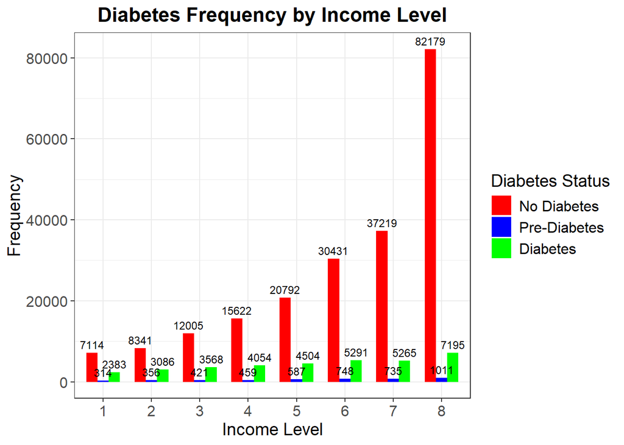

```r
# Tạo tần suất của các nhóm
freq_data <- as.data.frame(table(data$income, data$diabetes_012))
colnames(freq_data) <- c("income", "diabetes_012", "frequency")

# Chuyển đổi cột thành kiểu số
freq_data$income <- as.factor(freq_data$income)
freq_data$diabetes_012 <- as.factor(freq_data$diabetes_012)

# Vẽ biểu đồ
ggplot(freq_data, aes(x = income, y = frequency, fill = diabetes_012)) +
    geom_bar(stat = "identity", position = "dodge", width = 0.7) +
    geom_text(aes(label = frequency),
                        position = position_dodge(width = 0.7),
                        vjust = -0.5,
                        size = 3) +
    labs(
        title = "Diabetes Frequency by Income Level",
        x = "Income Level",
        y = "Frequency",
        fill = "Diabetes Status"
    ) +
    scale_fill_manual(
        values = c("red", "blue", "green"),
        labels = c("No Diabetes", "Pre-Diabetes", "Diabetes")
    ) +
    theme_bw() +
    theme(
        plot.title = element_text(size = 16, face = "bold", hjust = 0.5),
        axis.title = element_text(size = 14),
        axis.text = element_text(size = 12),
        legend.title = element_text(size = 14),
        legend.text = element_text(size = 12)
    )
```

**Mức thu nhập thấp (1 - 3)**: - **Mức 1**: Nhóm **Không tiểu đường** chiếm 7,114, trong khi **Tiểu đường** chỉ đạt 2,383. - **Mức 2**: Nhóm **Không tiểu đường** tăng lên 8,341, và nhóm **Tiểu đường** tăng lên 3,086. - **Mức 3**: Nhóm **Không tiểu đường** đạt 12,005, và nhóm **Tiểu đường** là 3,568.

**Mức thu nhập trung bình (4 - 6)**: - **Mức 4**: Nhóm **Không tiểu đường** tăng lên 15,622, trong khi nhóm **Tiểu đường** là 4,054. - **Mức 5**: Nhóm **Không tiểu đường** đạt 20,792, và nhóm **Tiểu đường** là 4,504. - **Mức 6**: Nhóm **Không tiểu đường** tăng đáng kể lên 30,431, và nhóm **Tiểu đường** đạt 5,291.

**Mức thu nhập cao (7 - 8)**: - **Mức 7**: Nhóm **Không tiểu đường** đạt 37,219, và nhóm **Tiểu đường** là 5,265. - **Mức 8**: Nhóm **Không tiểu đường** cao nhất, đạt 82,179, trong khi nhóm **Tiểu đường** là 7,195.

**Nhận xét**: Tần suất **Không tiểu đường** tăng mạnh theo mức thu nhập, đặc biệt ở các mức thu nhập cao (7 - 8). Tỷ lệ **Tiểu đường** cũng tăng lên nhưng với tốc độ chậm hơn, cho thấy mức thu nhập có thể ảnh hưởng tích cực đến khả năng quản lý sức khỏe và phòng ngừa bệnh tiểu đường.

# V. A/B Testing

## Tiền xử lý cơ bản

```r
library(janitor)
library(tidyverse)
library(ggplot2)
```

```r
data <- read.csv("data/diabetes_012_health_indicators_BRFSS2015.csv", na=c("", "NA", "N/A")) |> clean_names()
glimpse(data)
```

```
## Rows: 253,680
## Columns: 22
## $ diabetes_012           <dbl> 0, 0, 0, 0, 0, 0, 0, 0, 2, 0, 2, 0, 0, 2, 0, 0,…
## $ high_bp                <dbl> 1, 0, 1, 1, 1, 1, 1, 1, 1, 0, 0, 1, 0, 1, 0, 1,…
## $ high_chol              <dbl> 1, 0, 1, 0, 1, 1, 0, 1, 1, 0, 0, 1, 0, 1, 1, 0,…
## $ chol_check             <dbl> 1, 0, 1, 1, 1, 1, 1, 1, 1, 1, 1, 1, 1, 1, 1, 1,…
## $ bmi                    <dbl> 40, 25, 28, 27, 24, 25, 30, 25, 30, 24, 25, 34,…
## $ smoker                 <dbl> 1, 1, 0, 0, 0, 1, 1, 1, 1, 0, 1, 1, 1, 0, 1, 0,…
## $ stroke                 <dbl> 0, 0, 0, 0, 0, 0, 0, 0, 0, 0, 0, 0, 0, 0, 1, 0,…
## $ heart_diseaseor_attack <dbl> 0, 0, 0, 0, 0, 0, 0, 0, 1, 0, 0, 0, 0, 0, 0, 0,…
## $ phys_activity          <dbl> 0, 1, 0, 1, 1, 1, 0, 1, 0, 0, 1, 0, 0, 0, 1, 1,…
## $ fruits                 <dbl> 0, 0, 1, 1, 1, 1, 0, 0, 1, 0, 1, 1, 0, 0, 0, 0,…
## $ veggies                <dbl> 1, 0, 0, 1, 1, 1, 0, 1, 1, 1, 1, 1, 1, 1, 1, 0,…
## $ hvy_alcohol_consump    <dbl> 0, 0, 0, 0, 0, 0, 0, 0, 0, 0, 0, 0, 0, 0, 0, 0,…
## $ any_healthcare         <dbl> 1, 0, 1, 1, 1, 1, 1, 1, 1, 1, 1, 1, 1, 1, 1, 1,…
## $ no_docbc_cost          <dbl> 0, 1, 1, 0, 0, 0, 0, 0, 0, 0, 0, 0, 0, 0, 1, 0,…
## $ gen_hlth               <dbl> 5, 3, 5, 2, 2, 2, 3, 3, 5, 2, 3, 3, 3, 4, 4, 2,…
## $ ment_hlth              <dbl> 18, 0, 30, 0, 3, 0, 0, 0, 30, 0, 0, 0, 0, 0, 30…
## $ phys_hlth              <dbl> 15, 0, 30, 0, 0, 2, 14, 0, 30, 0, 0, 30, 15, 0,…
## $ diff_walk              <dbl> 1, 0, 1, 0, 0, 0, 0, 1, 1, 0, 0, 1, 0, 1, 0, 0,…
## $ sex                    <dbl> 0, 0, 0, 0, 0, 1, 0, 0, 0, 1, 1, 0, 0, 0, 0, 0,…
## $ age                    <dbl> 9, 7, 9, 11, 11, 10, 9, 11, 9, 8, 13, 10, 7, 11…
## $ education              <dbl> 4, 6, 4, 3, 5, 6, 6, 4, 5, 4, 6, 5, 5, 4, 6, 6,…
## $ income                 <dbl> 3, 1, 8, 6, 4, 8, 7, 4, 1, 3, 8, 1, 7, 6, 2, 8,…
```

```r
unique_counts <- data.frame(
    variable = names(data),
    unique_count = sapply(data, function(x) length(unique(x)))
)
qualitative_vars <- unique_counts |> filter(unique_count <= 13) |> pull(variable)
data[qualitative_vars] <- lapply(data[qualitative_vars], as.factor)
```

```r
glimpse(data)
```

```
## Rows: 253,680
## Columns: 22
## $ diabetes_012           <fct> 0, 0, 0, 0, 0, 0, 0, 0, 2, 0, 2, 0, 0, 2, 0, 0,…
## $ high_bp                <fct> 1, 0, 1, 1, 1, 1, 1, 1, 1, 0, 0, 1, 0, 1, 0, 1,…
## $ high_chol              <fct> 1, 0, 1, 0, 1, 1, 0, 1, 1, 0, 0, 1, 0, 1, 1, 0,…
## $ chol_check             <fct> 1, 0, 1, 1, 1, 1, 1, 1, 1, 1, 1, 1, 1, 1, 1, 1,…
## $ bmi                    <dbl> 40, 25, 28, 27, 24, 25, 30, 25, 30, 24, 25, 34,…
## $ smoker                 <fct> 1, 1, 0, 0, 0, 1, 1, 1, 1, 0, 1, 1, 1, 0, 1, 0,…
## $ stroke                 <fct> 0, 0, 0, 0, 0, 0, 0, 0, 0, 0, 0, 0, 0, 0, 1, 0,…
## $ heart_diseaseor_attack <fct> 0, 0, 0, 0, 0, 0, 0, 0, 1, 0, 0, 0, 0, 0, 0, 0,…
## $ phys_activity          <fct> 0, 1, 0, 1, 1, 1, 0, 1, 0, 0, 1, 0, 0, 0, 1, 1,…
## $ fruits                 <fct> 0, 0, 1, 1, 1, 1, 0, 0, 1, 0, 1, 1, 0, 0, 0, 0,…
## $ veggies                <fct> 1, 0, 0, 1, 1, 1, 0, 1, 1, 1, 1, 1, 1, 1, 1, 0,…
## $ hvy_alcohol_consump    <fct> 0, 0, 0, 0, 0, 0, 0, 0, 0, 0, 0, 0, 0, 0, 0, 0,…
## $ any_healthcare         <fct> 1, 0, 1, 1, 1, 1, 1, 1, 1, 1, 1, 1, 1, 1, 1, 1,…
## $ no_docbc_cost          <fct> 0, 1, 1, 0, 0, 0, 0, 0, 0, 0, 0, 0, 0, 0, 1, 0,…
## $ gen_hlth               <fct> 5, 3, 5, 2, 2, 2, 3, 3, 5, 2, 3, 3, 3, 4, 4, 2,…
## $ ment_hlth              <dbl> 18, 0, 30, 0, 3, 0, 0, 0, 30, 0, 0, 0, 0, 0, 30…
## $ phys_hlth              <dbl> 15, 0, 30, 0, 0, 2, 14, 0, 30, 0, 0, 30, 15, 0,…
## $ diff_walk              <fct> 1, 0, 1, 0, 0, 0, 0, 1, 1, 0, 0, 1, 0, 1, 0, 0,…
## $ sex                    <fct> 0, 0, 0, 0, 0, 1, 0, 0, 0, 1, 1, 0, 0, 0, 0, 0,…
## $ age                    <fct> 9, 7, 9, 11, 11, 10, 9, 11, 9, 8, 13, 10, 7, 11…
## $ education              <fct> 4, 6, 4, 3, 5, 6, 6, 4, 5, 4, 6, 5, 5, 4, 6, 6,…
## $ income                 <fct> 3, 1, 8, 6, 4, 8, 7, 4, 1, 3, 8, 1, 7, 6, 2, 8,…
```

## Chi Squared Test với biến định tính

```r
## Create a function to perform chi-square test and return results
chi_square_results <- lapply(qualitative_vars[qualitative_vars != "diabetes_012"], function(var) {
    contingency_table <- table(data[[var]], data$diabetes_012)
    chi_test <- chisq.test(contingency_table)

    data.frame(
        variable = var,
        chi_square = chi_test$statistic,
        df = chi_test$parameter,
        p_value = chi_test$p.value
    )
})
## Combine results into a single dataframe
results_df <- do.call(rbind, chi_square_results)
results_df <- results_df |>
    arrange(desc(chi_square)) ##|>
    ## mutate(p_value = format.pval(p_value))
results_df
```

```
##                           variable  chi_square df       p_value
## X-squared12               gen_hlth 24248.10615  8  0.000000e+00
## X-squared                  high_bp 18794.64405  2  0.000000e+00
## X-squared13              diff_walk 12776.94189  2  0.000000e+00
## X-squared1               high_chol 11258.92040  2  0.000000e+00
## X-squared15                    age  9641.37653 24  0.000000e+00
## X-squared5  heart_diseaseor_attack  8244.88911  2  0.000000e+00
## X-squared17                 income  7816.46291 14  0.000000e+00
## X-squared16              education  4560.64028 10  0.000000e+00
## X-squared6           phys_activity  3789.30146  2  0.000000e+00
## X-squared4                  stroke  2916.75198  2  0.000000e+00
## X-squared2              chol_check  1173.74936  2 1.329124e-255
## X-squared3                  smoker  1010.51175  2 3.716732e-220
## X-squared8                 veggies   893.84191  2 8.029646e-195
## X-squared9     hvy_alcohol_consump   850.32405  2 2.261930e-185
## X-squared7                  fruits   454.34706  2  2.186703e-99
## X-squared11          no_docbc_cost   396.08182  2  9.815790e-87
## X-squared14                    sex   250.85058  2  3.376679e-55
## X-squared10         any_healthcare    69.07798  2  9.997881e-16
```

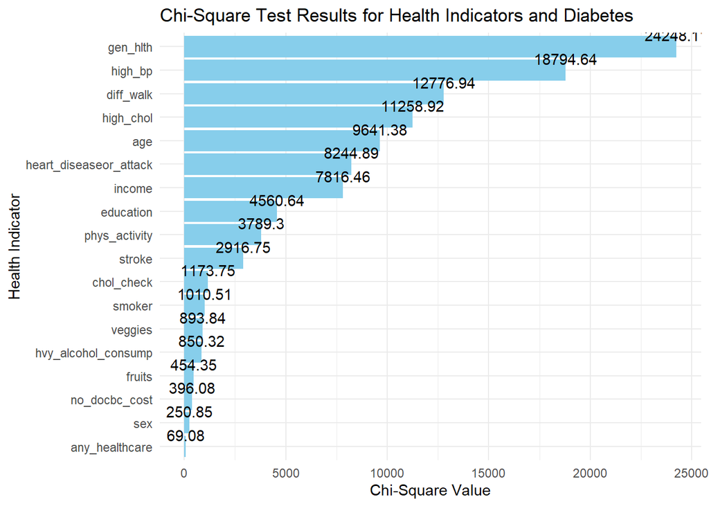

```r
## Plot the results
results_df |>
    ggplot(aes(x = reorder(variable, chi_square), y = chi_square)) +
    geom_bar(stat = "identity", fill = "skyblue") +
    geom_text(aes(label = round(chi_square, 2)), vjust = -0.5) +
    coord_flip() +
    labs(
        title = "Chi-Square Test Results for Health Indicators and Diabetes",
        x = "Health Indicator",
        y = "Chi-Square Value"
    ) +
    theme_minimal()
```

```r
## Create a function to perform chi-square test with Monte Carlo simulation
set.seed(42)
chi_square_results <- lapply(qualitative_vars[qualitative_vars != "diabetes_012"], function(var) {
    contingency_table <- table(data[[var]], data$diabetes_012)
    chi_test <- chisq.test(contingency_table, simulate.p.value = TRUE, B = 10000)

    data.frame(
        variable = var,
        chi_square = chi_test$statistic,
        ## df = chi_test$parameter,
        p_value = chi_test$p.value
    )
})

## Combine results into a single dataframe
results_df <- do.call(rbind, chi_square_results)
results_df <- results_df |>
    arrange(desc(chi_square)) |>
    mutate(
        signficance = case_when(
            p_value < 0.001 ~ "***",
            p_value < 0.01 ~ "**",
            p_value < 0.05 ~ "*",
            TRUE ~ "ns"
        )
    )
results_df
```

```
##                           variable  chi_square   p_value signficance
## X-squared12               gen_hlth 24248.10615 9.999e-05         ***
## X-squared                  high_bp 18794.64405 9.999e-05         ***
## X-squared13              diff_walk 12776.94189 9.999e-05         ***
## X-squared1               high_chol 11258.92040 9.999e-05         ***
## X-squared15                    age  9641.37653 9.999e-05         ***
## X-squared5  heart_diseaseor_attack  8244.88911 9.999e-05         ***
## X-squared17                 income  7816.46291 9.999e-05         ***
## X-squared16              education  4560.64028 9.999e-05         ***
## X-squared6           phys_activity  3789.30146 9.999e-05         ***
## X-squared4                  stroke  2916.75198 9.999e-05         ***
## X-squared2              chol_check  1173.74936 9.999e-05         ***
## X-squared3                  smoker  1010.51175 9.999e-05         ***
## X-squared8                 veggies   893.84191 9.999e-05         ***
## X-squared9     hvy_alcohol_consump   850.32405 9.999e-05         ***
## X-squared7                  fruits   454.34706 9.999e-05         ***
## X-squared11          no_docbc_cost   396.08182 9.999e-05         ***
## X-squared14                    sex   250.85058 9.999e-05         ***
## X-squared10         any_healthcare    69.07798 9.999e-05         ***
```

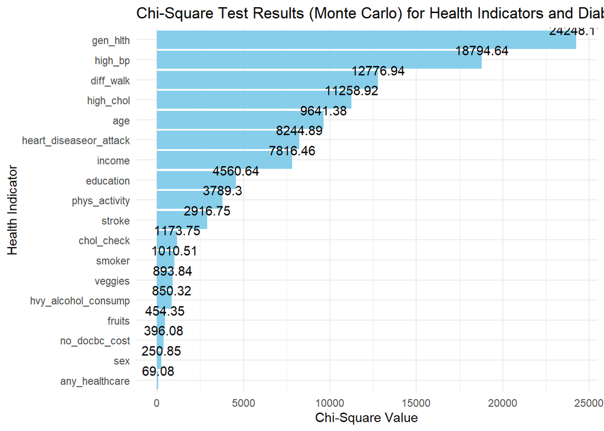

```r
## Plot the results
results_df |>
    ggplot(aes(x = reorder(variable, chi_square), y = chi_square)) +
    geom_bar(stat = "identity", fill = "skyblue") +
    geom_text(aes(label = round(chi_square, 2)), vjust = -0.5) +
    coord_flip() +
    labs(
        title = "Chi-Square Test Results (Monte Carlo) for Health Indicators and Diabetes",
        x = "Health Indicator",
        y = "Chi-Square Value"
    ) +
    theme_minimal()
```

### AB Testing

```r
bmi <- data |> group_by(diabetes_012) |> summarise(mean_bmi = mean(bmi), sd_bmi = sd(bmi), count = n())
bmi
```

```
## # A tibble: 3 × 4
##   diabetes_012 mean_bmi sd_bmi  count
##   <fct>           <dbl>  <dbl>  <int>
## 1 0                27.7   6.26 213703
## 2 1                30.7   6.96   4631
## 3 2                31.9   7.36  35346
```

Kết quả cho thấy số lượng người không bị tiểu đường chiếm đa số `213703`. Bên cạnh đó, chỉ số BMI trung bình của người bị tiểu đường cao hơn hẳn hai nhóm còn lại. Tuy nhiên, độ lệch chuẩn chỉ số BMI của nhóm bị tiểu đường cũng cao nhất, cho thấy độ biến động chỉ số BMI của nhóm này cao hơn nhóm không bị tiểu đường và tiền tiểu đường.

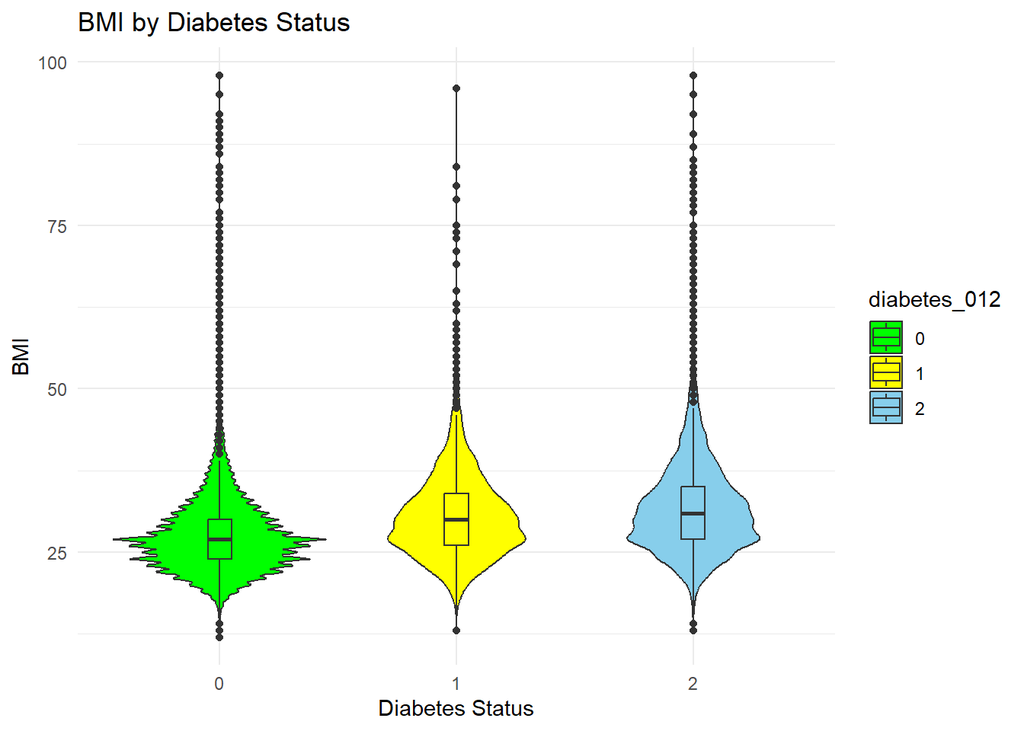

```r
## Plot BMI by diabetes status,violin plot
ggplot(data, aes(x = diabetes_012, y = bmi,fill=diabetes_012)) +
    geom_violin() + geom_boxplot(width = 0.1) +
    scale_fill_manual(values = c("green", "yellow", "skyblue"),breaks = c("0","1","2")) +
    labs(title = "BMI by Diabetes Status",
         x = "Diabetes Status",
         y = "BMI") +
    theme_minimal()
```

Ta thực hiện kiểm định ANOVA để kiểm định về sự khác biệt về chỉ số BMI trung bình giữa ba nhóm bệnh nhân.

```r
library(lmPerm)
set.seed(42)
aov_result <- aov(bmi ~ diabetes_012, data = data)
summary(aov_result)
```

```
##                  Df   Sum Sq Mean Sq F value Pr(>F)
## diabetes_012      2   561268  280634    6768 <2e-16 ***
## Residuals    253677 10518121      41
## ---
## Signif. codes:  0 '***' 0.001 '**' 0.01 '*' 0.05 '.' 0.1 ' ' 1
```

Bảng kết quả này cho thấy biến `diabetes_012` (với 2 bậc tự do) giải thích một phần đáng kể biến thiên của `bmi` và có giá trị F rất lớn (6768) kèm p-value < 2e-16. Điều đó chứng tỏ sự khác nhau giữa các nhóm `diabetes_012` về giá trị `bmi` là có ý nghĩa thống kê rất cao (mức ý nghĩa ***).

```r
ment_hlth <- data |> group_by(diabetes_012) |> summarise(mean_ment_hlth = mean(ment_hlth), sd_ment_hlth = sd(ment_hlth), count = n())
ment_hlth
```

```
## # A tibble: 3 × 4
##   diabetes_012 mean_ment_hlth sd_ment_hlth  count
##   <fct>                 <dbl>        <dbl>  <int>
## 1 0                      2.94         7.06 213703
## 2 1                      4.53         8.90   4631
## 3 2                      4.46         8.95  35346
```

Ta nhận thấy có sự khác biệt về trung bình của chỉ số `ment_hlth` ở ba nhóm bệnh nhân. Bên cạnh đó, độ biến động của chỉ số này ở ba nhóm cũng khác nhau.

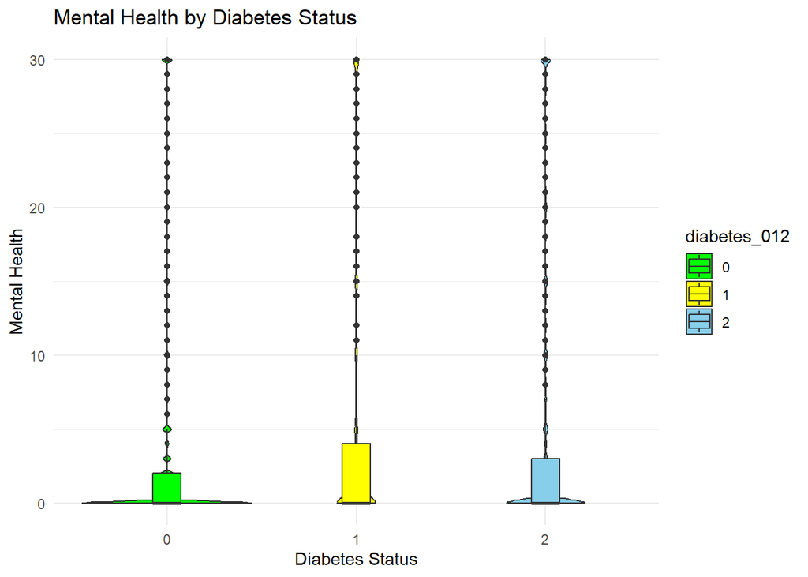

```r
## Plot mental health by diabetes status, violin plot
ggplot(data, aes(x = diabetes_012, y = ment_hlth,fill=diabetes_012)) +
    geom_violin() + geom_boxplot(width = 0.15) +
    scale_fill_manual(values = c("green", "yellow", "skyblue"),breaks = c("0","1","2")) +
    labs(title = "Mental Health by Diabetes Status",
         x = "Diabetes Status",
         y = "Mental Health") +
    theme_minimal()
```

Ta thực hiện kiểm định ANOVA để kiểm định sự khác biệt về chỉ số `ment_hlth` giữa ba nhóm bệnh nhân.

```r
set.seed(42)
aov_result <- aov(ment_hlth ~ diabetes_012, data = data)
summary(aov_result)
```

```
##                  Df   Sum Sq Mean Sq F value Pr(>F)
## diabetes_012      2    78369   39185   717.1 <2e-16 ***
## Residuals    253677 13861367      55
## ---
## Signif. codes:  0 '***' 0.001 '**' 0.01 '*' 0.05 '.' 0.1 ' ' 1
```

Biến `diabetes_012` có ảnh hưởng đáng kể đến `ment_hlth`, với giá trị F rất lớn (717.1) và p-value cực nhỏ (< 2e-16), cho thấy sự khác biệt giữa các nhóm `diabetes_012` về `ment_hlth` là có ý nghĩa thống kê rất cao.

```r
phys_hlth <- data |> group_by(diabetes_012) |> summarise(mean_phys_hlth = mean(phys_hlth), sd_phys_hlth = sd(phys_hlth), count = n())
phys_hlth
```

```
## # A tibble: 3 × 4
##   diabetes_012 mean_phys_hlth sd_phys_hlth  count
##   <fct>                 <dbl>        <dbl>  <int>
## 1 0                      3.58         8.00 213703
## 2 1                      6.35        10.3    4631
## 3 2                      7.95        11.3   35346
```

Ta nhận thấy có sự khác biệt về trung bình chỉ sô `phys_hlth`, ở đó nhóm bệnh nhân bị tiểu đường có số ngày gặp vấn đề về thể chất đứng đầu. Độ biến động ở ba nhóm này cũng rất khác biệt.

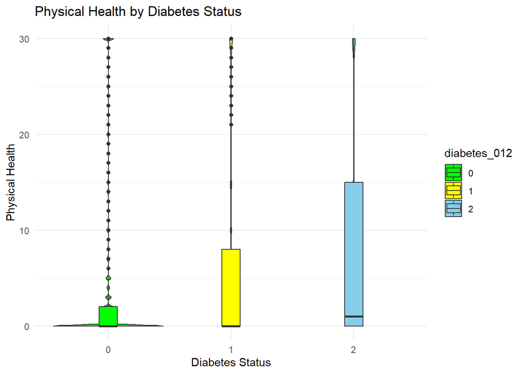

```r
## Plot physical health by diabetes status, violin plot
ggplot(data, aes(x = diabetes_012, y = phys_hlth,fill=diabetes_012)) +
    geom_violin() + geom_boxplot(width = 0.15) +
    scale_fill_manual(values = c("green", "yellow", "skyblue"),breaks = c("0","1","2")) +
    labs(title = "Physical Health by Diabetes Status",
         x = "Diabetes Status",
         y = "Physical Health") +
    theme_minimal()
```

```r
set.seed(42)
aov_result <- aov(phys_hlth ~ diabetes_012, data = data)
summary(aov_result)
```

```
##                  Df   Sum Sq Mean Sq F value Pr(>F)
## diabetes_012      2   600673  300337    4079 <2e-16 ***
## Residuals    253677 18679609      74
## ---
## Signif. codes:  0 '***' 0.001 '**' 0.01 '*' 0.05 '.' 0.1 ' ' 1
```

Biến `diabetes_012` có ảnh hưởng đáng kể đến `phys_hlth`, với giá trị F rất lớn (4079) và p-value cực nhỏ (< 2e-16), cho thấy sự khác biệt giữa các nhóm `diabetes_012` về `phys_hlth` là có ý nghĩa thống kê rất cao.

#### AB Testing

```r
bmi <- data |> group_by(diabetes_012) |> summarise(mean_bmi = mean(bmi), sd_bmi = sd(bmi), count = n())
bmi
```

```
## # A tibble: 3 × 4
##   diabetes_012 mean_bmi sd_bmi  count
##   <fct>           <dbl>  <dbl>  <int>
## 1 0                27.7   6.26 213703
## 2 1                30.7   6.96   4631
## 3 2                31.9   7.36  35346
```

Kết quả cho thấy số lượng người không bị tiểu đường chiếm đa số `213703`. Bên cạnh đó, chỉ số BMI trung bình của người bị tiểu đường cao hơn hẳn hai nhóm còn lại. Tuy nhiên, độ lệch chuẩn chỉ số BMI của nhóm bị tiểu đường cũng cao nhất, cho thấy độ biến động chỉ số BMI của nhóm này cao hơn nhóm không bị tiểu đường và tiền tiểu đường.

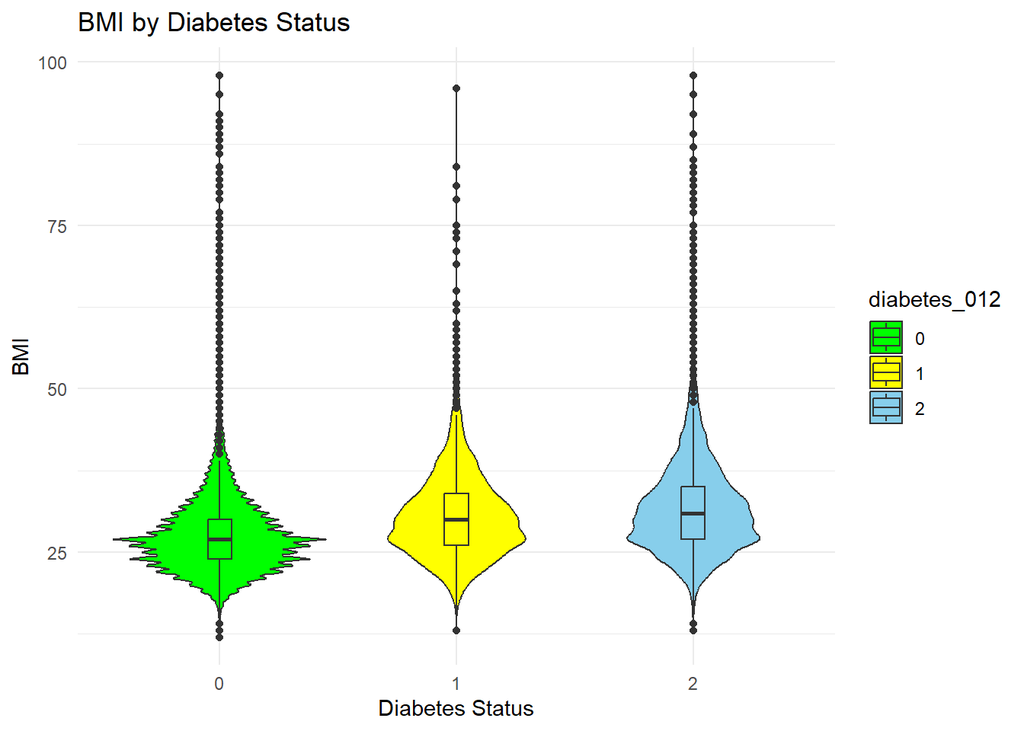

```r
## Plot BMI by diabetes status,violin plot
ggplot(data, aes(x = diabetes_012, y = bmi,fill=diabetes_012)) +
    geom_violin() + geom_boxplot(width = 0.1) +
    scale_fill_manual(values = c("green", "yellow", "skyblue"),breaks = c("0","1","2")) +
    labs(title = "BMI by Diabetes Status",
         x = "Diabetes Status",
         y = "BMI") +
    theme_minimal()
```

Ta thực hiện kiểm định ANOVA để kiểm định về sự khác biệt về chỉ số BMI trung bình giữa ba nhóm bệnh nhân.

```r
library(lmPerm)
set.seed(42)
aov_result <- aov(bmi ~ diabetes_012, data = data)
summary(aov_result)
```

```
##                  Df   Sum Sq Mean Sq F value Pr(>F)
## diabetes_012      2   561268  280634    6768 <2e-16 ***
## Residuals    253677 10518121      41
## ---
## Signif. codes:  0 '***' 0.001 '**' 0.01 '*' 0.05 '.' 0.1 ' ' 1
```

Bảng kết quả này cho thấy biến `diabetes_012` (với 2 bậc tự do) giải thích một phần đáng kể biến thiên của `bmi` và có giá trị F rất lớn (6768) kèm p-value < 2e-16. Điều đó chứng tỏ sự khác nhau giữa các nhóm `diabetes_012` về giá trị `bmi` là có ý nghĩa thống kê rất cao (mức ý nghĩa ***).

```r
ment_hlth <- data |> group_by(diabetes_012) |> summarise(mean_ment_hlth = mean(ment_hlth), sd_ment_hlth = sd(ment_hlth), count = n())
ment_hlth
```

```
## # A tibble: 3 × 4
##   diabetes_012 mean_ment_hlth sd_ment_hlth  count
##   <fct>                 <dbl>        <dbl>  <int>
## 1 0                      2.94         7.06 213703
## 2 1                      4.53         8.90   4631
## 3 2                      4.46         8.95  35346
```

Ta nhận thấy có sự khác biệt về trung bình của chỉ số `ment_hlth` ở ba nhóm bệnh nhân. Bên cạnh đó, độ biến động của chỉ số này ở ba nhóm cũng khác nhau.

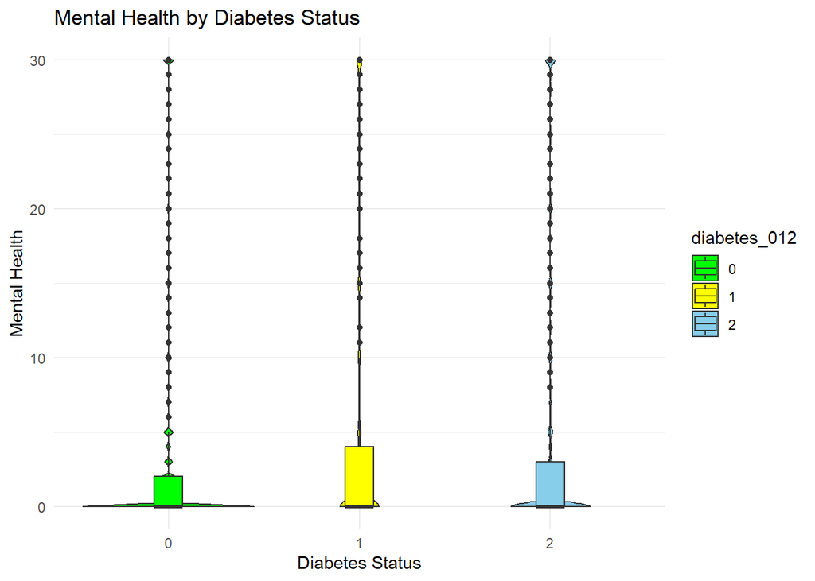

```r
## Plot mental health by diabetes status, violin plot
ggplot(data, aes(x = diabetes_012, y = ment_hlth,fill=diabetes_012)) +
    geom_violin() + geom_boxplot(width = 0.15) +
    scale_fill_manual(values = c("green", "yellow", "skyblue"),breaks = c("0","1","2")) +
    labs(title = "Mental Health by Diabetes Status",
         x = "Diabetes Status",
         y = "Mental Health") +
    theme_minimal()
```

Ta thực hiện kiểm định ANOVA để kiểm định sự khác biệt về chỉ số `ment_hlth` giữa ba nhóm bệnh nhân.

```r
set.seed(42)
aov_result <- aov(ment_hlth ~ diabetes_012, data = data)
summary(aov_result)
```

```
##                  Df   Sum Sq Mean Sq F value Pr(>F)
## diabetes_012      2    78369   39185   717.1 <2e-16 ***
## Residuals    253677 13861367      55
## ---
## Signif. codes:  0 '***' 0.001 '**' 0.01 '*' 0.05 '.' 0.1 ' ' 1
```

Biến `diabetes_012` có ảnh hưởng đáng kể đến `ment_hlth`, với giá trị F rất lớn (717.1) và p-value cực nhỏ (< 2e-16), cho thấy sự khác biệt giữa các nhóm `diabetes_012` về `ment_hlth` là có ý nghĩa thống kê rất cao.

```r
phys_hlth <- data |> group_by(diabetes_012) |> summarise(mean_phys_hlth = mean(phys_hlth), sd_phys_hlth = sd(phys_hlth), count = n())
phys_hlth
```

```
## # A tibble: 3 × 4
##   diabetes_012 mean_phys_hlth sd_phys_hlth  count
##   <fct>                 <dbl>        <dbl>  <int>
## 1 0                      3.58         8.00 213703
## 2 1                      6.35        10.3    4631
## 3 2                      7.95        11.3   35346
```

Ta nhận thấy có sự khác biệt về trung bình chỉ sô `phys_hlth`, ở đó nhóm bệnh nhân bị tiểu đường có số ngày gặp vấn đề về thể chất đứng đầu. Độ biến động ở ba nhóm này cũng rất khác biệt.

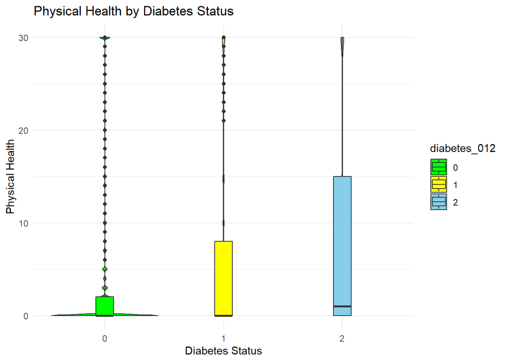

```r
## Plot physical health by diabetes status, violin plot
ggplot(data, aes(x = diabetes_012, y = phys_hlth,fill=diabetes_012)) +
    geom_violin() + geom_boxplot(width = 0.15) +
    scale_fill_manual(values = c("green", "yellow", "skyblue"),breaks = c("0","1","2")) +
    labs(title = "Physical Health by Diabetes Status",
         x = "Diabetes Status",
         y = "Physical Health") +
    theme_minimal()
```

```r
set.seed(42)
aov_result <- aov(phys_hlth ~ diabetes_012, data = data)
summary(aov_result)
```

```
##                  Df   Sum Sq Mean Sq F value Pr(>F)
## diabetes_012      2   600673  300337    4079 <2e-16 ***
## Residuals    253677 18679609      74
## ---
## Signif. codes:  0 '***' 0.001 '**' 0.01 '*' 0.05 '.' 0.1 ' ' 1
```

Biến `diabetes_012` có ảnh hưởng đáng kể đến `phys_hlth`, với giá trị F rất lớn (4079) và p-value cực nhỏ (< 2e-16), cho thấy sự khác biệt giữa các nhóm `diabetes_012` về `phys_hlth` là có ý nghĩa thống kê rất cao.